# **Sarah Djeddi, PhD**

## Postdoctoral Research Fellow

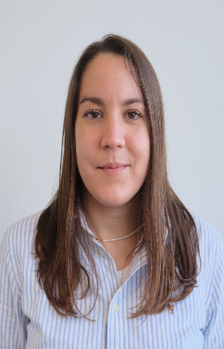

**Affiliation:** Boston Children’s Hospital, Harvard Medical School  
**Division:** Immunology  
**Department:** Pediatrics  
**Lab:** Gutierrez-Arcelus Lab

# **Getting to know Sarah**

It is no question why we sat down with Sarah for this edition of the CDN Researcher Spotlight…her work, passion and recent success speaks for itself. Before we dive in, let us tell you a little bit about Sarah:

She is a French computational biologist with a PhD in bioinformatics from Strasbourg University. She has worked on a vast amount of research projects in her professional career and recently has published a preprint on the relation between Rhinovirus infections and childhood-onset asthma.

# **Who or what motivated Sarah to get to where she is? What motivates Sarah now?**

*Sarah did her PhD in the Institute of Genetics, Molecular and Cellular Biology in France where she worked on integrating omics data to better understand congenital diseases. During that time she developed intellectual curiosity about complex genetic diseases and how to better understand them. This was a key motivating factor to carry out her postdoctoral work at Maria Gutierrez-Arcelus’ lab at BCH since she is a key referent in the functional genomics field which aims to integrate genetics with other data modalities to draw relations between a persons genotype and their phenotype.*

# **What values guide her decision making?**

*Her key driving force is to improve patients’ lives. She aims to do this by furthering our understanding of disease etiology, the causal mechanisms that develop into a disease, by jointly studying different data modalities.*

# **The study that became the preprint:**

# **“Could you summarize to the general public why you decided to carry out this study and what are the main takeaways?”**

*“Here in the lab of Maria Gutierrez-Arcelus we are interested in understanding the molecular mechanisms of immune-mediated diseases by using a combination of genetic and multi-omics approaches.*

*Asthma is one of the themes we are studying in the lab since we know it is a disease influenced by genetics and the environment, however we only understand some part of the genetic origin. Only 47% of risk loci co-localize with leukocyte T-cell, a cell type that is part of the immune system, and has been associated with the genetics of asthma. So we decided to tackle this question by thinking about other cell types that are under-studied in the context of asthma and in functional genomics studies. Epithelial cells for instance, is another main cell type studied for asthma but not usually from the genetic perspective; so we decided to focus on those cell types; because Epithelial cells are the first line of contact for respiratory viruses and allergens. Moreover; Epidemiological studies have shown that viral infections in early life are associated with childhood asthma development and it remains unclear whether Rhinovirus is causal in asthma or whether it is a biomarker for children already predisposed to asthma.”*

# **“Keeping in mind the general public, could you briefly explain what are GWAS and how are you incorporating them into this study?”**

*“I will start with an introduction about GWAS, which stands for Genome-wide association study and it aims to identify associations of genotypes with phenotypes by testing for differences in the allele frequency of genetic variants between individuals that differ phenotypically. The summary statistic obtained from a genome-wide association study is what is obtained from such an analysis; you can think of millions of variants that will have an associated P-value and then we can assess which of those variants are associated with the disease.*

*In our study we are combining single-cell RNA-seq data and GWAS data by looking at genes that are over-expressed in a specific context (ex: genes being upregulated upon rhinovirus infection or genes being upregulated upon asthma). And then we checked if those genes carry more variants (enrichment) than expected by chance. If so, we observe an enrichment of GWAS variants in a given cell type; and in our case we found an enrichment of childhood-onset asthma variants in epithelial cells infected with rhinovirus*.”

# **“What do you think is the power of using single-cell technologies?”**

*“Single-cell technologies are great for many reasons, compared to more ancestral methods where we would analyze bulk populations of cells, single cells allow researchers to study individual cells. Bulk methods provide a snapshot of the overall population, whereas single-cell analysis captures the dynamics of individual cells over time. These single-cells technologies allow to identify cell subset/state in a more fine grain manner, this permit to identify rare cell types and understand better their roles and potential mechanisms associated with them. We can also use single-cell technologie understand better cell-cell interactions and communication.”*

# **“Could you elaborate on how identifying epithelial cells as key cells expressing asthma-associated genes can lead to better treatment or prevention of asthma?”**

*“The identification of airway epithelial cells infected with rhinovirus, and specifically non-ciliated cells as being the one upregulating asthma-associated genes help to better understand the genetic origin of childhood-onset asthma. It has been shown in the literature that drug targets that have genetic evidence are more likely to be approved and then move forward to clinical trial.”*

# **“If you could carry out further analysis, what would you like to have done?”**

*“Now our results represent preliminary results from cells taken from a few individuals (10-20 individuals), if we could replicate our results in cohorts of larger sample size (1000-15000 individuals) it would be ideal. In that way we could identify the likely causal variants that regulate the likely genes and this will help to identify more precisely the underlying molecular mechanisms. We would also need functional validations to prove and understand better our findings, we could think about CRISPR strategy for example. Finally, if our findings are further validated we could imagine the development of a rhinovirus vaccine or other protective intervention in order to prevent childhood-onset asthma.”*

**Abstract**: Sarah Djeddi aims to better understand the genetic and environmental influences on asthma. Our understanding of its genetic origins remains limited, with only 47% of risk loci co-localizing with leukocyte T-cells, a known immune system component linked to asthma genetics. To address, under-studied cell types they combined single-cell RNA-seq and GWAS data, focusing on genes overexpressed in specific contexts. They showed how epithelial cells, specifically non-ciliated cells as being the one upregulating asthma-associated genes. These findings could help us better understand the genetic origin of childhood-onset asthma and aid in drug development.